# induction_questions

Joe LaRocca

2024-11-21

# Problem 1

```r
fram_heart = read_csv("data/frmgham2.csv") |>
  janitor::clean_names()
```

# Problem 2

### Calculate mean BMI for female and male participants

```r
female_mean_bmi = fram_heart |>
  filter(sex == 2) |>
  pull(bmi) |>
  mean(na.rm = TRUE) |>
  round(2)

male_mean_bmi = fram_heart |>
  filter(sex == 1) |>
  pull(bmi) |>
  mean(na.rm = TRUE) |>
  round(2)
```

### Impute data for missing BMI

```r
for(i in 1:nrow(fram_heart)){
  if(is.na(fram_heart[i, "bmi"])) {
    if(fram_heart[i, "sex"] == 2) {
      fram_heart[i, "bmi"] = female_mean_bmi
    } else if(fram_heart[i, "sex"] == 1) {
      fram_heart[i, "bmi"] = male_mean_bmi
    }
  }
}
```

There are no missing data for systolic blood pressure (`sysbp`) or diabetes (`diabetes`), so no adjustments were necessary for either of those variables.

# Problem 3

```r
fram_heart |>
  group_by(sex, diabetes) |>
  summarize(n = n(),
            mean_bmi = mean(bmi),
            sd_bmi = sd(bmi),
            min_bmi = min(bmi),
            median_bmi = median(bmi),
            max_bmi = max(bmi)) |>
  knitr::kable(digits = 2)
```

[output not shown]

| sex | diabetes | n | mean_bmi | sd_bmi | min_bmi | median_bmi | max_bmi |
| --- | --- | --- | --- | --- | --- | --- | --- |
| 1 | 0 | 4769 | 26.16 | 3.39 | 14.43 | 26.09 | 45.43 |
| 1 | 1 | 253 | 26.96 | 3.95 | 17.17 | 26.30 | 40.23 |
| 2 | 0 | 6328 | 25.52 | 4.40 | 14.53 | 24.79 | 56.80 |
| 2 | 1 | 277 | 28.11 | 6.33 | 16.36 | 27.66 | 56.80 |

From this table, we can see that women with diabetes ($n = 277$) have both the largest mean BMI ($28.11$) and largest variation $s = 6.33$ in BMI. Women *without* diabetes ($n = 6328$) have the smallest mean BMI ($25.52$).

It’s worth noting that due to the longitudinal nature of the dataset, some individuals are counted multiple times in this table (at different time points). Also, only a small portion of participants (4.56%) have diabetes, so the sample sizes for the diabetic groups are much smaller than the sample sizes for the non-diabetic groups.

# Problem 4

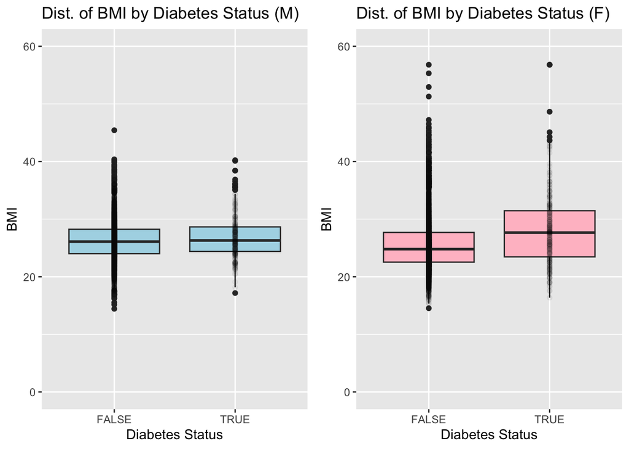

```r
male_bmi_plot = fram_heart |>
  filter(sex == 1) |>
  mutate(diabetes = as.logical(diabetes)) |>
  ggplot(aes(x = diabetes, y = bmi)) +
    geom_boxplot(fill = "lightblue") +
    labs(
      x = "Diabetes Status",
      y = "BMI",
      title = "Dist. of BMI by Diabetes Status (M)"
    ) +
    geom_point(alpha = 0.05) +
    scale_y_continuous(limits = c(0, 60))

female_bmi_plot = fram_heart |>
  filter(sex == 2) |>
  mutate(diabetes = as.logical(diabetes)) |>
  ggplot(aes(x = diabetes, y = bmi)) +
    geom_boxplot(fill = "pink") +
    labs(
      x = "Diabetes Status",
      y = "BMI",
      title = "Dist. of BMI by Diabetes Status (F)"
    ) +
    geom_point(alpha = 0.05) +
    scale_y_continuous(limits = c(0, 60))

plot_grid(male_bmi_plot, female_bmi_plot)
```

# Problem 5

```r
lm_simple = lm(bmi ~ sex + diabetes, data = fram_heart)
summary(lm_simple)
```

```
##
## Call:
## lm(formula = bmi ~ sex + diabetes, data = fram_heart)
##
## Residuals:
##      Min       1Q   Median       3Q      Max
## -11.6864  -2.6659  -0.4164   2.1436  31.2441
##
## Coefficients:
##             Estimate Std. Error t value Pr(>|t|)
## (Intercept) 26.67677    0.12569 212.240  < 2e-16 ***
## sex         -0.56041    0.07617  -7.357 2.01e-13 ***
## diabetes     1.73570    0.18090   9.595  < 2e-16 ***
## ---
## Signif. codes:  0 '***' 0.001 '**' 0.01 '*' 0.05 '.' 0.1 ' ' 1
##
## Residual standard error: 4.068 on 11624 degrees of freedom
## Multiple R-squared:  0.01266,    Adjusted R-squared:  0.01249
## F-statistic: 74.54 on 2 and 11624 DF,  p-value: < 2.2e-16
```

From our model, we see that the `sex` coefficient is negative, so we can conclude that on average, women have a lower mean BMI than men when accounting for diabetes status (since women are coded as “2” and men are coded as “1”). This is an interesting conclusion, as we saw from our table in Problem 3 that women with diabetes have a higher average BMI than men with diabetes. One reason why the model’s results could be the way they are is that overall, women do have a lower mean BMI, and the sample sizes for non-diabetic men and women are much larger than the sample sizes for diabetic men and women.

The $P$-value for the sex-coefficient is far less than $0.05$, implying that there is a statistically significant difference in mean BMI for women and men even when accounting for diabetes status.

Additional covariates we could use include age, total cholesterol and glucose levels in the blood, smoking status, or the number of cigarettes used per day. While smoking status is a binary variable, the other variables are continuous.

# Problem 6

```r
lm_interaction = lm(bmi ~ sex + diabetes + sex * diabetes,
                    data = fram_heart)

summary(lm_interaction)
```

```
##
## Call:
## lm(formula = bmi ~ sex + diabetes + sex * diabetes, data = fram_heart)
##
## Residuals:
##      Min       1Q   Median       3Q      Max
## -11.7481  -2.6402  -0.4138   2.1362  31.2798
##
## Coefficients:
##              Estimate Std. Error t value Pr(>|t|)
## (Intercept)  26.80736    0.12830 208.944  < 2e-16 ***
## sex          -0.64357    0.07793  -8.259  < 2e-16 ***
## diabetes     -0.99908    0.58066  -1.721   0.0854 .
## sex:diabetes  1.79348    0.36189   4.956  7.3e-07 ***
## ---
## Signif. codes:  0 '***' 0.001 '**' 0.01 '*' 0.05 '.' 0.1 ' ' 1
##
## Residual standard error: 4.064 on 11623 degrees of freedom
## Multiple R-squared:  0.01474,    Adjusted R-squared:  0.01449
## F-statistic: 57.98 on 3 and 11623 DF,  p-value: < 2.2e-16
```

In order to explore if the effect of diabetes status on BMI differed for men and women, we could add an interaction term (`sex * diabetes`). Since the interaction term is statistically significant ($P << 0.05$), we can conclude that there is a significant difference in the relationship between diabetes status and BMI based on gender.

Specifically, when interpreting the regression coefficients, we would add the `sex:diabetes` coefficient once to our estimate if the participant is a man with diabetes and twice if the participant is a woman with diabetes. For example, for a woman with diabetes, our BMI estimate would be $26.807 - 2(0.644) - 0.999 + 2(1.793) = 28.108$, which nearly exactly matches the mean BMI for women with diabetes that we calculated in problem 3.

One key assumption in this model is that each observation is independent, but as we noted in Problem 3, some individuals are counted multiple times in the data. Therefore, data points representing the same person are inherently correlated, and thus not independent.

# Problem 7

### Create a function to detect whether a participant quit smoking

```r
quit_smoke = function(df){
  qs = NULL
  qs[1] = FALSE
  for(i in 2:nrow(df)) {
    if(df[i, "randid"] == df[i-1, "randid"]) {
      if(df[i, "cursmoke"] == df[i-1, "cursmoke"] - 1){
        qs[i] = TRUE
      } else if(qs[i-1] == TRUE) {
        qs[i] = TRUE
      } else {
        qs[i] = FALSE
      }
    } else {
      qs[i] = FALSE
    }
  }
  return(qs)
}
```

### Put the new quit variable into the data frame

```r
fram_heart = fram_heart |>
  mutate(quit = quit_smoke(fram_heart))
```

### Find the participants who quit smoking

```r
quit_smokers = fram_heart |>
  select(randid, quit) |>
  filter(quit == TRUE) |>
  distinct()

nrow(quit_smokers)
```

```
## [1] 665
```

We can see that over the course of the study, 665 people quit smoking. I created a function called `quit_smoke` that creates a logical vector that tracks whether each participant has quit smoking, and remains true for participants’ subsequent study visits (that way, we can analyze systolic blood pressure before and after smoking for Problem #8).

# Problem 8

### Create a new data frame for only those who quit smoking at some point

```r
fram_heart_quit = fram_heart |>
  filter(randid %in% quit_smokers$randid)
```

### Create summary table for systolic BP before and after quitting

```r
fram_heart_quit |>
  group_by(quit) |>
  summarize(mean_bp = mean(sysbp)) |>
  knitr::kable(digits = 2)
```

| quit | mean_bp |
| --- | --- |
| FALSE | 131.88 |
| TRUE | 139.20 |

On average, we can see that systolic blood pressue was actually *higher* after quitting smoking than before quitting, with means of $139.20$ and $131.88$, respectively.

# Problem 9

### Create function to get BP change only directly after quitting smoking

```r
bpChange = function(df){
  bp_change = NULL
  bp_change[1] = NA
  for(i in 2:nrow(df)) {
    if(df[i, "randid"] == df[i-1, "randid"]) {
      if(df[i, "quit"] == TRUE){
        if(df[i-1, "quit"] == TRUE){
          bp_change[i] = NA
        } else {
          bp_change[i] = df[i, "sysbp"] - df[i-1, "sysbp"]
        }
      } else {
        bp_change[i] = NA
      }
    } else {
      bp_change[i] = NA
    }
  }
  return(bp_change)
}
```

### Get a data frame filtered for participants IDs and their change in BP after quitting smoking

```r
change_df = fram_heart_quit |>
  select(randid, sysbp, quit) |>
  mutate(change = bpChange(fram_heart_quit)) |>
  unnest(change) |>
  filter(!is.na(change))
```

### Make a boxplot of changes in systolic BP before/after quitting

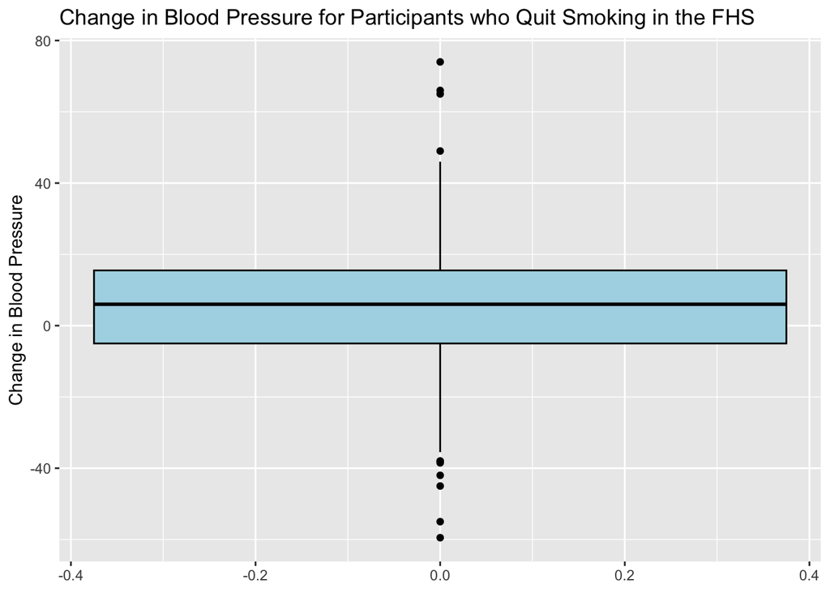

```r
change_df |>
  ggplot(aes(y = change)) +
  geom_boxplot(fill = "lightblue", col = "black") +
  labs(
    y = "Change in Blood Pressure",
    title = "Change in Blood Pressure for Participants who Quit Smoking in the FHS"
  )
```

From the boxplot, we can see that the distribution in the changes in systolic blood pressure from before quitting smoking to the first study visit after quitting is symmetric, with few outliers, and centered around a blood pressure *gain* of about 5 mmHg. This is slightly surprising, as conventional wisdom would say that quitting smoking leads to lower blood pressure (and particularly a reduction in hypertension risk), but there are other factors – such as increased age – that could potentially explain the positive difference in systolic blood pressure over time.

# Problem 10

Printing out the command `sessioninfo::session_info()` gives the version of R being used, the current computer operating system, the date, and all packages that have been installed by the user, among other information. This can potentially be useful when syncing data and R Markdown documents across different versions of R, as not all users may have the latest version of R.